# RNA-Seq Analysis

Erica Lam

2021 September 08

## Introduction

This report seeks to answer how the Bcl6 transcriptional repressor functions in the immune system.

Two conditions were assessed in triplicates. Endogenous Bcl6-depleted OCI-LY1 cells were rescued with either WT Bcl6 or RD mutant Bcl6. Mutant RD2 domain disrupts Bcl6 repressor function. RD2 domain is essential for pre-GC B cell differentiation and clustering into nascent GC within follicles. Here, RD2 is repressed by repressing key trafficking receptors S1pr1 and Gpr183 through Hdac2 recruitment.

The dataset (SRP043078) was obtained using recount2 and was loaded with its metadata here:

```r
# load in data (SRP043078)
load("Datasets/rse_gene.Rdata")

# sample info; add prefix to column names
sra <- read.csv("Datasets/SraRunTable.txt")
colnames(sra) <- paste0("sra_", colnames(sra))
# choose variable
sra_var <- paste0("sra_", "Genotype")
# reorganize and append
sra <- sra[match(colData(rse_gene)$run, sra$sra_Run), ]

condition <- sra[, sra_var]
colData(rse_gene) <- cbind(colData(rse_gene), condition)
dim(colData(rse_gene))
colData(rse_gene)[, 1:ncol(colData(rse_gene))]
```

[output not shown]

## DESeq analysis

The top statistically significant DEGs are shown:

```r
# SE to DDS
dds <- DESeqDataSet(rse_gene, ~condition)

# perform DE analysis and get result out... log2(mutant/WT)
dds$condition <- relevel(dds$condition, ref = "siBCL6;etopic expression of WT BCL6")
dds <- DESeq(dds)
res <- results(dds, contrast = c("condition", "siBCL6;etopic expression of BCL6 RD2 mutant", "siBCL6;etopic expression of WT BCL6"))

# normalize
resapeglm <- lfcShrink(dds = dds, type = "apeglm", coef = 2)

# create results table and annotate genes
write.table(resapeglm, file = "allgenes_adjp0.01_lfc1_bm20.txt",
            sep = "\t", col.names = TRUE, row.names = TRUE)

row.names(resapeglm) <- gsub("\\..*","",row.names(resapeglm))

anno <- AnnotationDbi::select(org.Hs.eg.db, rownames(resapeglm),
                              columns=c("ENSEMBL", "ENTREZID", "SYMBOL", "GENENAME"),
                              keytype="ENSEMBL")
resapeglm <- cbind(ENSEMBL = rownames(resapeglm), resapeglm)
anno_res <- left_join(as.data.frame(resapeglm), anno)

# filter criteria for statistically significant results
pThr        <- 0.01
logFCThr    <- 1
baseMeanThr <- 20

idx <- which(anno_res$padj <= pThr &
              abs(anno_res$log2FoldChange) >= logFCThr &
              anno_res$baseMean >= baseMeanThr)
anno_sigres <- anno_res[idx, ]

DT::datatable(anno_sigres, class = "hover", options = list(scrollX = TRUE))
```

|  | ENSEMBL | baseMean | log2FoldChange | lfcSE | pvalue | padj | ENTREZID | SYMBOL | GENENAME |
| --- | --- | --- | --- | --- | --- | --- | --- | --- | --- |
| 6 | ENSG00000000938 | 2714.25433713422 | -1.44324364092601 | 0.179013452929398 | 6.75486173704641e-17 | 7.86077844700659e-16 | 2268 | FGR | FGR proto-oncogene, Src family tyrosine kinase |
| 52 | ENSG00000004399 | 40006.749988024 | 2.67299549640918 | 0.0850553543563324 | 1.85887395054839e-217 | 6.67939066985208e-215 | 23129 | PLXND1 | plexin D1 |
| 66 | ENSG00000004838 | 970.639835598471 | 1.03587866507895 | 0.346356268355 | 0.000319311359849495 | 0.00138142050160735 | 51364 | ZMYND10 | zinc finger MYND-type containing 10 |
| 107 | ENSG00000005513 | 2007.20776609547 | -3.55159604391561 | 0.360922236456996 | 3.89727077216363e-24 | 6.28766847735875e-23 | 30812 | SOX8 | SRY-box transcription factor 8 |
| 129 | ENSG00000006118 | 2241.71179003428 | -2.25943983818067 | 0.237260696889904 | 1.06100088260788e-22 | 1.61029192865012e-21 | 54972 | TMEM132A | transmembrane protein 132A |
| 145 | ENSG00000006555 | 447.234108881259 | -2.69064466778637 | 0.532840065398635 | 2.18233855383323e-08 | 1.45121971072517e-07 | 55001 | TTC22 | tetratricopeptide repeat domain 22 |
| 153 | ENSG00000006652 | 207595.075435878 | 1.38431916325742 | 0.035449204010908 | 0 | 0 | 3475 | IFRD1 | interferon related developmental regulator 1 |
| 172 | ENSG00000007129 | 1182.81541062317 | 1.64686951078662 | 0.27849704761785 | 2.5692183586688e-10 | 1.99399188378458e-09 | 90273 | CEACAM21 | CEA cell adhesion molecule 21 |
| 178 | ENSG00000007237 | 948.94239632579 | 1.44717101605039 | 0.323922286050456 | 6.57776779203542e-07 | 3.85361988079443e-06 | 8522 | GAS7 | growth arrest specific 7 |
| 195 | ENSG00000007866 | 3326.99182013771 | 1.00671558759056 | 0.180232838793641 | 3.39053525510515e-09 | 2.4145774627064e-08 | 7005 | TEAD3 | TEA domain transcription factor 3 |

[output cut: 1807 more lines]

## Data quality

Replicates of the samples are observed to cluster well together and suggest the experimental conditions to be a major cause of variation.

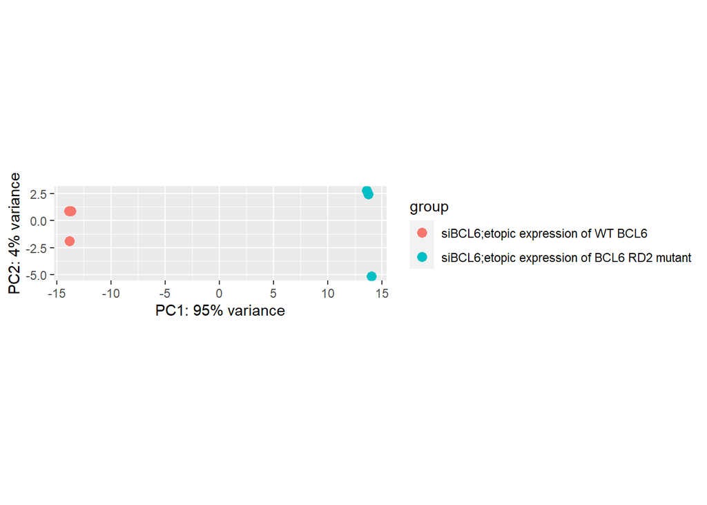

```r
row.names(dds) <- gsub("\\..*","",row.names(dds))
rld <- rlog(dds)
plotPCA(rld, intgroup = "condition")
```

## Top DEGs

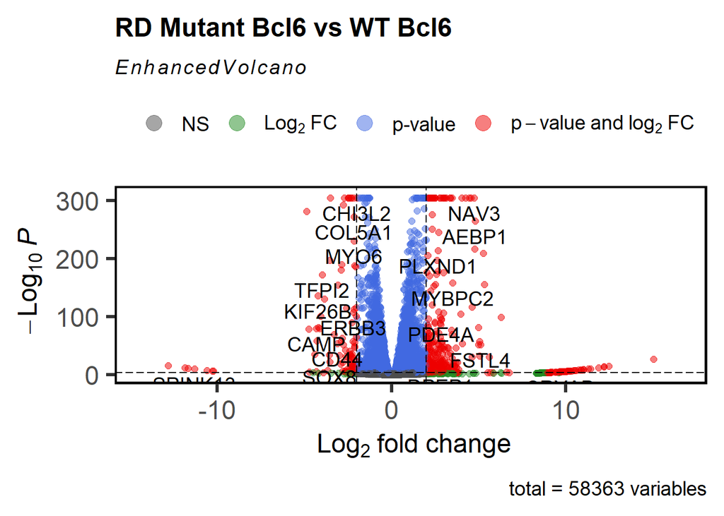

```r
EnhancedVolcano(anno_res, lab = anno_res$SYMBOL, x = "log2FoldChange",
                y = "padj", border = "full", borderWidth = 1.5, borderColour = "black",
                gridlines.major = FALSE, gridlines.minor = FALSE, title = "RD Mutant Bcl6 vs WT Bcl6",
                pCutoff = 10e-5, FCcutoff = 2)
```

The top up-regulated and down-regulated DEGS ordered by LFC are shown, respectively.

### Under-expressed DEGs

While several novel transcripts were underexpressed, more-studied genes positively correlate to serine and ion channels in WT Bcl6. The down regulation of MIR200CHG, SPINK13, CAMP, and NAV2 suggests Bcl6 to repress transcription related to cell maturation, proliferation, and migration of inflammatory cells. Negative correlation of the genes in mutant RD2 Bcl6 demonstrate RD2 to play a role in the inhibitive effect of Bcl6 and great division between the conditions.

The top under-expressed genes are listed: MIR200CHG regulates YB-1 phosphorylation at serine 102, which can promote tumor cell proliferation, apoptosis, and drug resistance (1). SPINK13 is a serine protease inhibitor and is associated with plasminogen deficiency, type I (2). CACNA2D3 encodes for the voltage-gated calcium channel complex, induces apoptosis, and could arrest cell cycle at the G1/S checkpoint (3). CAMP is characterized by antimicrobial activity, immune mediator induction, and inflammatory response regulation (4). PDZRN3 is related to ubiquitin-protein ligase activity (5). NCS1 is a neuronal calcium sensor and is associated with neuron differentiation by inhibiting N-type voltage-gated calcium channel activity (6). LINC01987 is an IncRNA (7). RAB19 is related to GTPase activity and immunodeficiency 54 (8). SCNN1B encodes for the beta subunit of the epithelial nonvoltage-gated sodium channel (9). CEROX1 modulates mitochondrial complex I activity (10). KIF26B transports organelles with microtubules (11). ODAPH encodes a phosphoprotein for enamel mineralization (12). NLRP4 negatively regulates autophagy and is important in NF-kB inhibition (13). NAV2 is a neuron navigator involved in cellular growth and migration (14). ENPP7P8 is a pseudogene (15).

1. https://www.nature.com/articles/s41523-021-00293-x
2. https://www.genecards.org/cgi-bin/carddisp.pl?gene=SPINK13
3. https://www.genecards.org/cgi-bin/carddisp.pl?gene=CACNA2D3
4. https://www.genecards.org/cgi-bin/carddisp.pl?gene=CAMP
5. https://www.genecards.org/cgi-bin/carddisp.pl?gene=PDZRN3
6. https://www.genecards.org/cgi-bin/carddisp.pl?gene=NCS1
7. https://www.genecards.org/cgi-bin/carddisp.pl?gene=LINC01987
8. https://www.genecards.org/cgi-bin/carddisp.pl?gene=RAB19
9. https://www.genecards.org/cgi-bin/carddisp.pl?gene=SCNN1B
10. https://www.ncbi.nlm.nih.gov/pmc/articles/PMC6542586/
11. https://www.genecards.org/cgi-bin/carddisp.pl?gene=KIF26B
12. https://www.genecards.org/cgi-bin/carddisp.pl?gene=ODAPH
13. https://www.genecards.org/cgi-bin/carddisp.pl?gene=NLRP4
14. https://www.genecards.org/cgi-bin/carddisp.pl?gene=NAV2
15. https://www.genecards.org/cgi-bin/carddisp.pl?gene=ENPP7P8

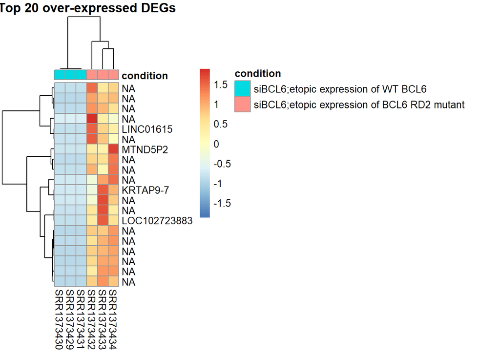

```r
# create a heatmap showing the top 20 over- and under-expressed DEGs
orderedsigres <- anno_sigres[order(anno_sigres$log2FoldChange, decreasing = TRUE), ]
mat <- assay(rld)
annotation <- as.data.frame(colData(rld)["condition"])
id1 <- orderedsigres$ENSEMBL
id2 <- orderedsigres$SYMBOL
topDEG <- mat[id1,]
rownames(topDEG) <- id2
top20DEG <- head(topDEG, n = 20)
rownames(annotation) <- colnames(rld)

pheatmap(top20DEG, scale = "row", clustering_distance_rows = "correlation",
         annotation_col = annotation, main = "Top 20 over-expressed DEGs")
```

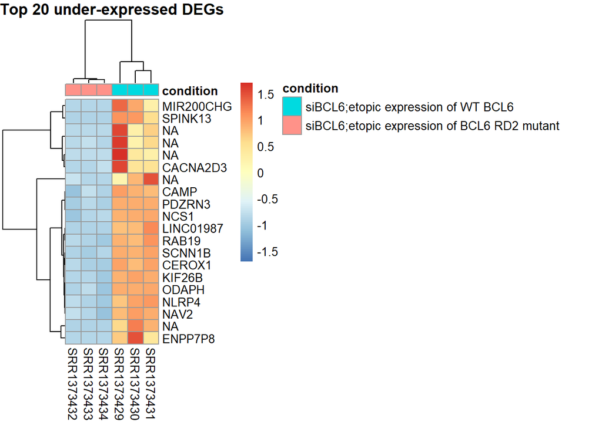

```r
orderedsigres <- anno_sigres[order(anno_sigres$log2FoldChange), ]
mat <- assay(rld)
annotation <- as.data.frame(colData(rld)["condition"])
id1 <- orderedsigres$ENSEMBL
id2 <- orderedsigres$SYMBOL
topDEG <- mat[id1,]
rownames(topDEG) <- id2
top20DEG <- head(topDEG, n = 20)
rownames(annotation) <- colnames(rld)

pheatmap(top20DEG, scale = "row", clustering_distance_rows = "correlation",
         annotation_col = annotation, main = "Top 20 under-expressed DEGs")
```

## GSEA analysis

### Top five over-expressed pathways

```r
# Do GSEA on the results and plot the top 5 pathways
# arrange by padj
anno_res2 <- anno_res %>%
  arrange(padj) %>%
  mutate(gsea_metric = -log10(padj) * sign(log2FoldChange))
# get rid of inf from ~0 padj values
anno_res2 <- anno_res2 %>%
  mutate(padj = case_when(padj == 0 ~ .Machine$double.xmin,
                          TRUE ~ padj)) %>%
  mutate(gsea_metric = -log10(padj) * sign(log2FoldChange))
# remove NAs and order by GSEA;
anno_res2 <- anno_res2 %>%
  filter(! is.na(gsea_metric)) %>%
  arrange(desc(gsea_metric))
# ranked GSEA vector
rnk <- anno_res2 %>%
  select(SYMBOL, gsea_metric) %>%
  distinct(SYMBOL, .keep_all = TRUE) %>%
  deframe()
# get gene sets
gene_sets <- msigdbr(species = "Homo sapiens", category = "C7")
gene_sets <- gene_sets %>%
  select(gs_name, gene_symbol)
# run GSEA
gseares <- GSEA(geneList = rnk, TERM2GENE = gene_sets)
gseares_df <- as.data.frame(gseares)

# top 5 pathways
top_pathways <- gseares_df %>%
  top_n(n = 5, wt = NES) %>%
  pull(ID)

top_pathways_plot <- lapply(top_pathways, function(pathway){
  gseaplot(gseares, geneSetID = pathway, title = pathway)
})
top_pathways_plot <- ggarrange(plotlist = top_pathways_plot, labels = "AUTO", align = "hv")

ggsave(top_pathways_plot, filename = "top_up_GSEA.png", height = 25, width = 45)

knitr::include_graphics("top_up_GSEA.png")
```

[figure not shown]

The top over-expressed pathways are based on NES using MSigDB immunologic signature gene sets. They are related to IL-10 activity, lymphocyte development, and pattern recognition receptor (PRR) pathways.

IL-10 is known to downregulate Th1 cytokines and NF-kB activity to enhance B cell survival. In T cell development, TCF-1 suppresses early stage malignant-developing thymocytes. PRRs mediate the initiation of antigen-specific immune response and release of inflammatory cytokines essential for anti-viral defense. These pathways suggest Bcl6 involvement in repressing cell proliferation, inflammatory responses, and lymphocyte development.